# Regression Practice

# Introduction

In this assignment, you will practice regression analysis including:

- Plotting bivariate data with a regression line
- Calculating and interpreting the correlation coefficient, r
- Fitting a linear regression analysis
- Verifying if a linear model is model is adequate:
  - Checking for linearity (scatterplot)
  - Checking for constant variance (`plot(lm_output, which=1)`)
  - Checking for normality of residuals (`qqPlot(lm_output$residuals)`)

```r
library(tidyverse)
library(mosaic)
library(rio)
library(car)
```

# Car Prices and Mileage

[figure not shown]

You are interested in purchasing an all wheel drive Acura MDX for those slick Rexburg winters. You found what you think is a good deal based on a low-mileage 2020 model but you’d like to be sure. You go on Autotrader.com and randomly select 23 Acura MDX’s and collect Price and Mileage information.

Load the data and use R to answer the questions below.

```r
cars <- import('https://github.com/byuistats/Math221D_Cannon/raw/master/Data/acuraMDX_price_vs_mileage.csv')
glimpse(cars)
```

```
Rows: 23
Columns: 2
$ Mileage     <int> 110298, 92950, 165165, 162115, 120198, 193000, 145949, 155…
$ `MDX Price` <int> 11991, 13995, 8750, 10995, 10500, 8495, 10000, 9499, 9995,…
```

Before you begin:

**What is the response/dependent variable?**  
Price

**What is the explanatory variable**  
Mileage  
**What do you think is the nature of the relationship between the two?**  
Likely negative; as mileage increases, price decreases.  
**How strong do you think the relationship is?**  
Moderately strong.

## Plot the Data and calculate r

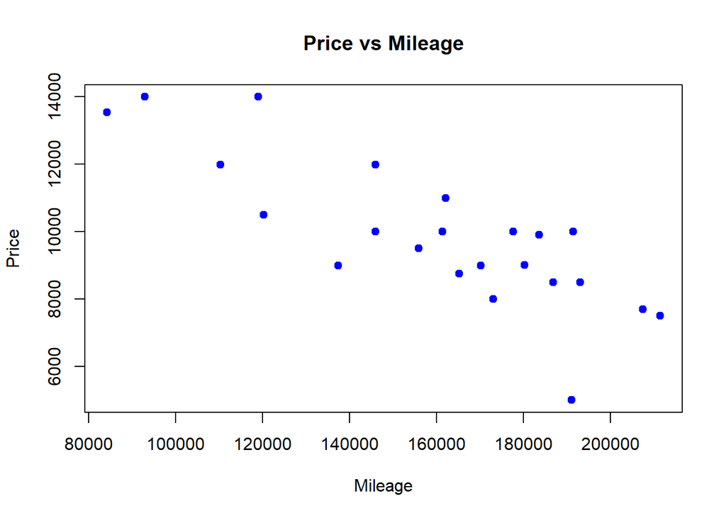

```r
plot(cars$Mileage, cars$`MDX Price`, main="Price vs Mileage", xlab="Mileage", ylab="Price", pch=19, col="blue")
```

```r
# Calculating the correlation coefficient
cor(cars$Mileage, cars$`MDX Price`)
```

```
[1] -0.8185192
```

**Does the relationship look linear?**  
Yes

**What is the correlation coefficient, r?**  
-0.8185192

**What does this r show?**  
Strong negative linear relationship between mileage and price.

## Fit a Linear Regression Model

```r
lm_output <- lm(`MDX Price` ~ Mileage, data = cars)

# Summary of the model
summary(lm_output)
```

```
Call:
lm(formula = `MDX Price` ~ Mileage, data = cars)

Residuals:
    Min      1Q  Median      3Q     Max
-3282.9  -562.4   170.8   893.5  2068.6

Coefficients:
              Estimate Std. Error t value Pr(>|t|)
(Intercept)  1.793e+04  1.261e+03  14.218 3.01e-12 ***
Mileage     -5.051e-02  7.736e-03  -6.529 1.81e-06 ***
---
Signif. codes:  0 '***' 0.001 '**' 0.01 '*' 0.05 '.' 0.1 ' ' 1

Residual standard error: 1274 on 21 degrees of freedom
Multiple R-squared:   0.67, Adjusted R-squared:  0.6543
F-statistic: 42.63 on 1 and 21 DF,  p-value: 1.813e-06
```

Add the regression line to your chart:

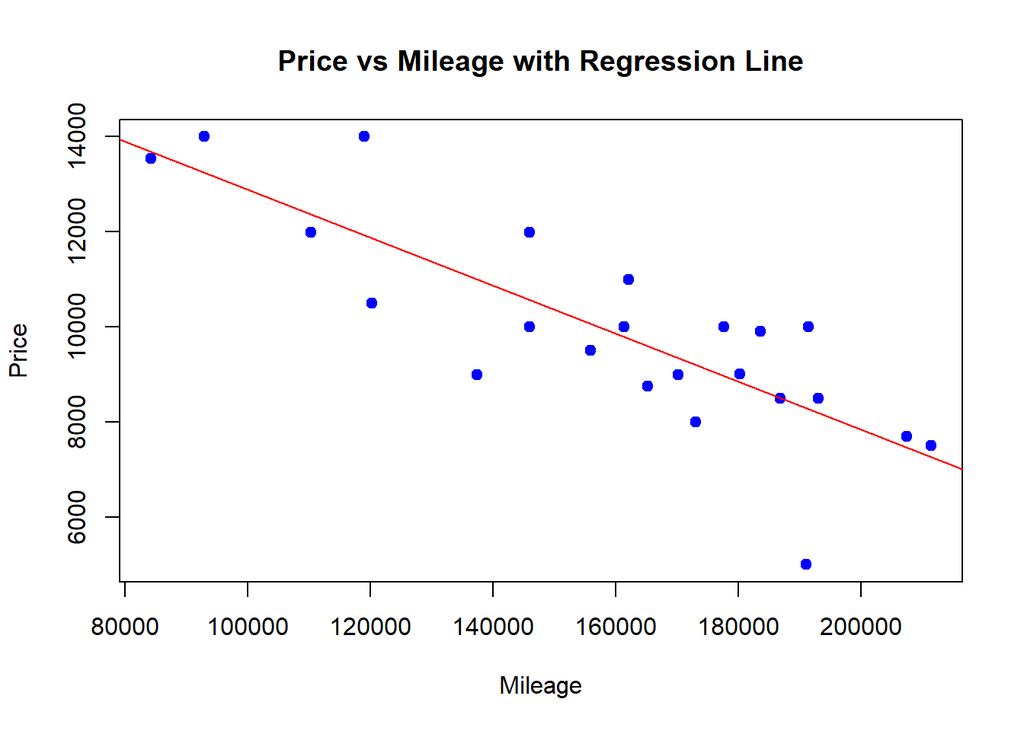

```r
# Sometimes you have to run the whole chunk with plot() and the abline() together:

#plot()
#abline(lm_output$coefficients)
plot(cars$Mileage, cars$`MDX Price`, main="Price vs Mileage with Regression Line", xlab="Mileage", ylab="Price", pch=19, col="blue")
abline(lm_output, col="red")
```

**What is the slope of the regression line, and what does it mean?**

The slope of the regression line is -5.051e-02. This means that for every additional mile driven, the price of the Acura MDX decreases by approximately $0.05051. This negative slope indicates a negative relationship between mileage and price.

**What is the intercept and what does it mean?**

The intercept is 1.793e+04. The intercept represents the estimated price of the Acura MDX when the mileage is zero. In this context, it is the starting price when the car is new (or has no mileage).

**What is your p-value?**

1.81e-06

**What is your conclusion?**

There is a strong and statistically significant negative relationship between the mileage of the Acura MDX and its price. As mileage increases, the price decreases significantly.

**What is the confidence interval for the slope?**  
[-0.0666, -0.0344]

```r
confint(lm_output)
```

```
                    2.5 %        97.5 %
(Intercept)  1.531030e+04  2.055629e+04
Mileage     -6.659524e-02 -3.442092e-02
```

Interpret the confidence interval.  
**The 95% confidence interval for the slope ranges from [-0.0666, -0.0344]. This interval does not include zero, which confirms that the relationship between mileage and price is statistically significant. The negative values in the interval reinforce the negative relationship between mileage and price.**

## Check Model Requirements

Check the normality of the residuals:

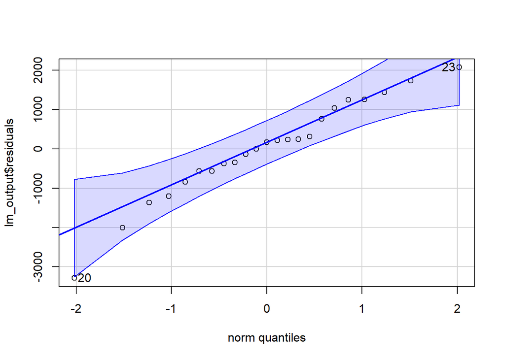

```
[1] 20 23
```

```r
qqPlot(lm_output$residuals)
```

Check for constant variance (Residual by Predicted plot):

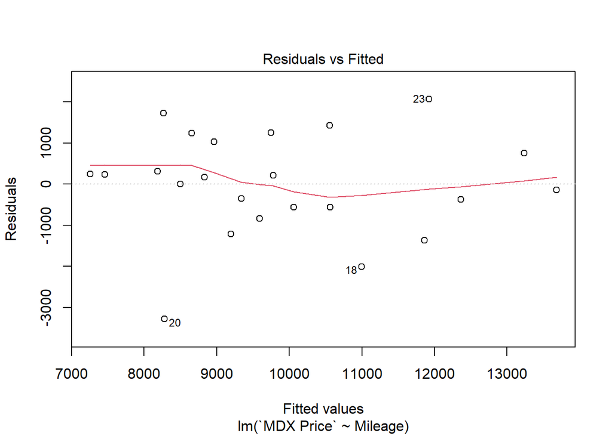

```r
plot(lm_output, which = 1)
```

Lastly, the car you’re interested in buying has around 100,000 miles and costs $11,200. Could this be considered a good deal? Why?  
**The predicted price for a car with 100,000 miles is approximately $12,882.48. Since the actual price of $11,200 is below the lower bound of the confidence interval ($11,778.82), it suggests that $11,200 is a good deal for a car with 100,000 miles.**

```r
deal_prediction <- predict(lm_output, newdata = data.frame(Mileage = 100000), interval = "confidence")
deal_prediction
```

```
       fit      lwr      upr
1 12882.48 11778.82 13986.15
```

# Manatee Deaths and Motorboat Registrations in Florida

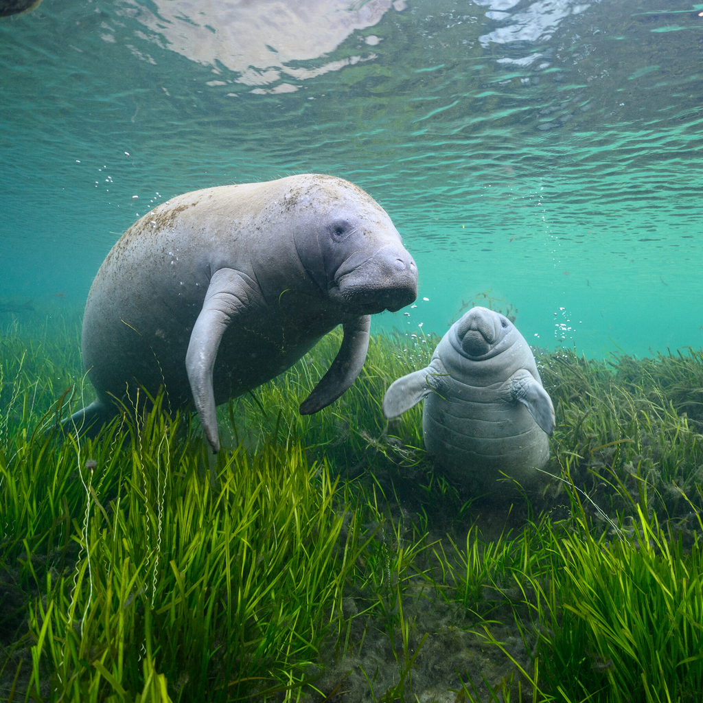

Florida is a fabulous place for experiencing wildlife and recreation. Unfortunately, sometimes those two activities conflict.

Researchers collected over 30 years of data about water craft registrations (motor and non-motor boats) and manatee deaths. The goal of the research is to evaluate the relationship between boat registrations and manatee deaths.

Before you begin:

**What is the response/dependent variable?**

Manatee deaths

**What is the explanatory variable**

Motorboat registrations

**What do you think is the nature of the relationship between the two?**

Likely positive; more registrations might lead to more manatee deaths.

**How strong do you think the relationship is?**

Not super strong.

Load the data:

```r
manatees <- import('https://github.com/byuistats/Math221D_Cannon/raw/master/Data/manatees.csv')
glimpse(manatees)
```

```
Rows: 35
Columns: 4
$ `Fiscal Year`             <int> 1977, 1978, 1979, 1980, 1981, 1982, 1983, 19…
$ `Power Boats (in 1000's)` <int> 436, 449, 470, 487, 502, 501, 515, 548, 575,…
$ Manatees                  <int> 14, 21, 18, 19, 24, 18, 20, 27, 30, 34, 31, …
$ Comments                  <chr> "Source for the Powerboat Data:", "Data for …
```

## Plot the Data and calculate r

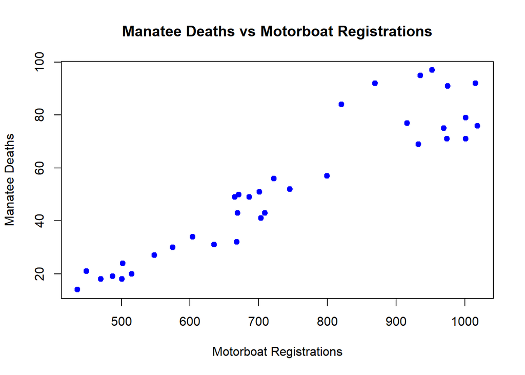

```r
plot(manatees$`Power Boats (in 1000's)`, manatees$Manatees, main="Manatee Deaths vs Motorboat Registrations", xlab="Motorboat Registrations", ylab="Manatee Deaths", pch=19, col="blue")
```

```r
cor(manatees$`Power Boats (in 1000's)`, manatees$Manatees)
```

```
[1] 0.9376368
```

**Does the relationship look linear?**

Yes

**What is the correlation coefficient, r?**

0.9376368

**What does this r show?**

This shows a very strong positive correlation.

## Fit a Linear Regression Model

```r
lm_output_manatees <- lm(Manatees ~ `Power Boats (in 1000's)`, data = manatees)


summary(lm_output_manatees)
```

```
Call:
lm(formula = Manatees ~ `Power Boats (in 1000's)`, data = manatees)

Residuals:
    Min      1Q  Median      3Q     Max
-15.736  -6.642  -1.239   4.374  22.309

Coefficients:
                            Estimate Std. Error t value Pr(>|t|)
(Intercept)               -42.525657   6.347072   -6.70 1.25e-07 ***
`Power Boats (in 1000's)`   0.129133   0.008334   15.49  < 2e-16 ***
---
Signif. codes:  0 '***' 0.001 '**' 0.01 '*' 0.05 '.' 0.1 ' ' 1

Residual standard error: 9.237 on 33 degrees of freedom
Multiple R-squared:  0.8792,    Adjusted R-squared:  0.8755
F-statistic: 240.1 on 1 and 33 DF,  p-value: < 2.2e-16
```

Add the regression line to your chart:

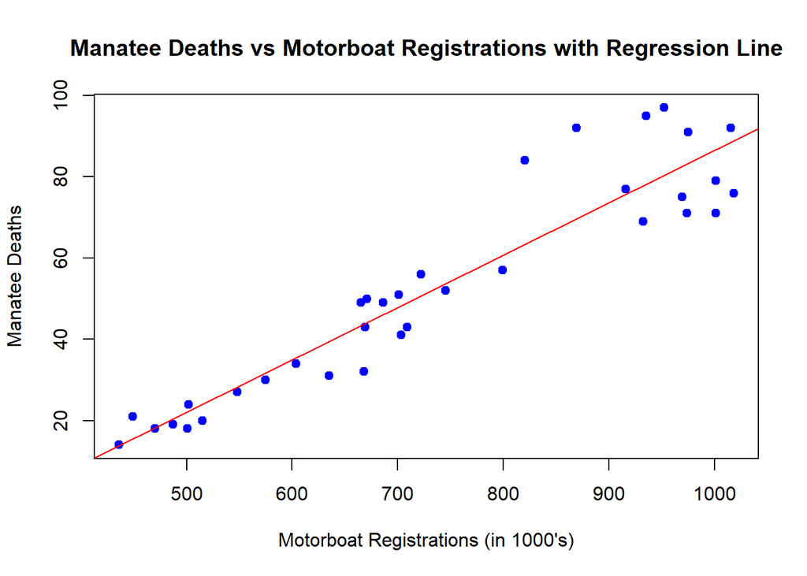

```r
plot(manatees$`Power Boats (in 1000's)`, manatees$Manatees, main="Manatee Deaths vs Motorboat Registrations with Regression Line", xlab="Motorboat Registrations (in 1000's)", ylab="Manatee Deaths", pch=19, col="blue")
abline(lm_output_manatees, col="red")
```

**What is the slope of the regression line, and what does it mean?**

The slope of the regression line is 0.1291. This means that for each additional thousand motorboat registrations, the number of manatee deaths increases by approximately 0.1291

**What is the intercept and what does it mean?**

The intercept is −42.53. This represents the estimated number of manatee deaths when there are zero motorboat registrations.

**What is your p-value?**

he p-value for the slope is < 2e-16, indicating a statistically significant relationship between motorboat registrations and manatee deaths.

**What is your conclusion?**

There is a strong and statistically significant positive relationship between the number of motorboat registrations and manatee deaths. As motorboat registrations increase, the number of manatee deaths also increases significantly.

**What is the confidence interval for the slope?**

[0.1122, 0.1461]

```r
confint(lm_output_manatees)
```

```
                                2.5 %      97.5 %
(Intercept)               -55.4388729 -29.6124417
`Power Boats (in 1000's)`   0.1121773   0.1460879
```

**Interpret the confidence interval:**

The 95% confidence interval for the slope is approximately [0.1122, 0.1461]. This range does not include zero, indicating a significant relationship.

## Check Model Requirements

Check the normality of the residuals:

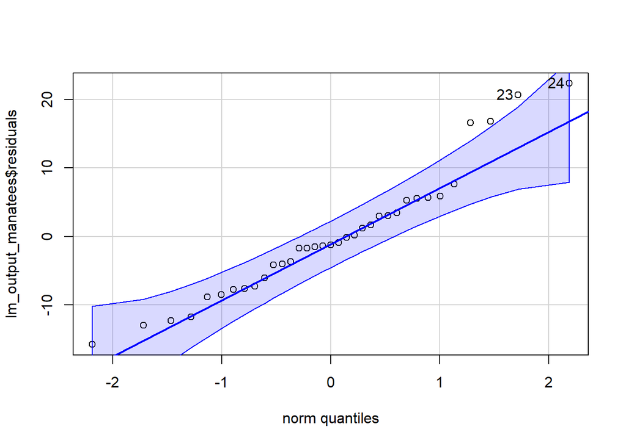

```
[1] 24 23
```

```r
qqPlot(lm_output_manatees$residuals)
```

Check for constant variance (Residual by Predicted plot):

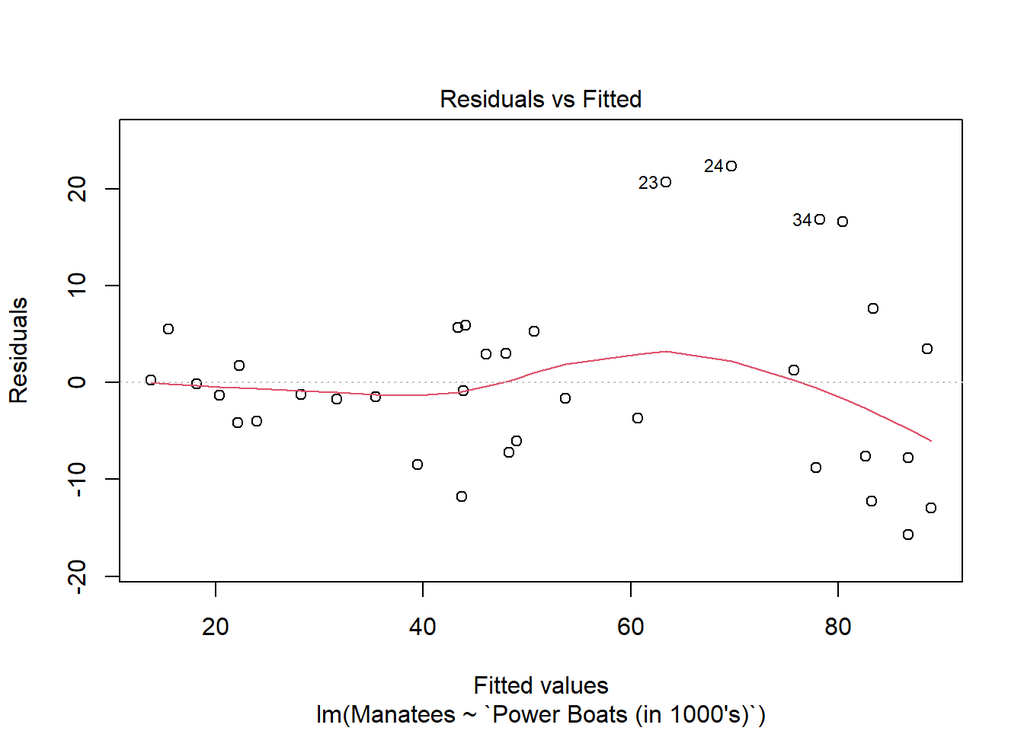

```r
plot(lm_output_manatees, which = 1)
```

# MCAT Score and GPA

[figure not shown]

The MCAT is an entrance exam for medical schools. It seems likely that there is a relationship between your undergraduate GPA and how well you do on the MCAT.

GPA and MCAT score data were collected on 55 prospective medical students.

Before you begin:

**What is the response/dependent variable?**

MCAT score

**What is the explanatory variable**

GPA

**What do you think is the nature of the relationship between the two?**

Likely positive; higher GPA might lead to higher MCAT scores.

**How strong do you think the relationship is?**

Moderately strong.

Load the data:

```r
mcat <- import('https://github.com/byuistats/Math221D_Cannon/raw/master/Data/mcat_gpa.csv')
glimpse(mcat)
```

```
Rows: 55
Columns: 2
$ GPA  <dbl> 3.62, 3.84, 3.23, 3.69, 3.38, 3.72, 3.89, 3.34, 3.71, 3.89, 3.97,…
$ MCAT <int> 38, 45, 33, 40, 35, 36, 40, 39, 35, 34, 39, 31, 35, 32, 32, 38, 3…
```

## Plot the Data and calculate r

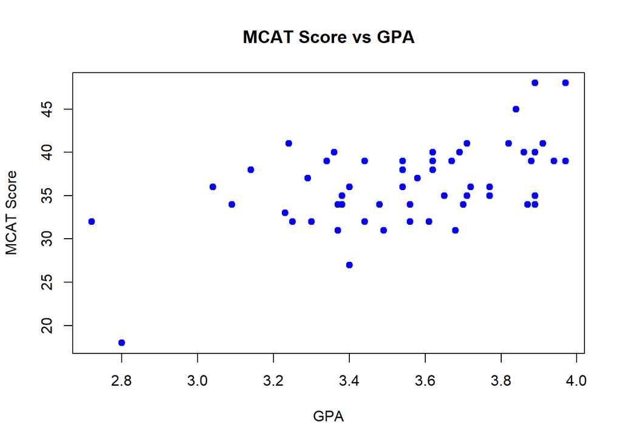

```r
plot(mcat$GPA, mcat$MCAT, main="MCAT Score vs GPA", xlab="GPA", ylab="MCAT Score", pch=19, col="blue")
```

```r
cor(mcat$GPA, mcat$MCAT)
```

```
[1] 0.5414202
```

**Does the relationship look linear?**

Somewhat

**What is the correlation coefficient, r?**

0.5414202

**What does this r show?**

Moderate positive linear relationship between GPA and MCAT scores.

## Fit a Linear Regression Model

```r
lm_output_mcat <- lm(MCAT ~ GPA, data = mcat)

summary(lm_output_mcat)
```

```
Call:
lm(formula = MCAT ~ GPA, data = mcat)

Residuals:
     Min       1Q   Median       3Q      Max
-11.4148  -2.5168  -0.1519   2.6653   8.6616

Coefficients:
            Estimate Std. Error t value Pr(>|t|)
(Intercept)    3.923      6.922   0.567    0.573
GPA            9.104      1.942   4.688 1.97e-05 ***
---
Signif. codes:  0 '***' 0.001 '**' 0.01 '*' 0.05 '.' 0.1 ' ' 1

Residual standard error: 4.088 on 53 degrees of freedom
Multiple R-squared:  0.2931,    Adjusted R-squared:  0.2798
F-statistic: 21.98 on 1 and 53 DF,  p-value: 1.969e-05
```

Add the regression line to your chart:

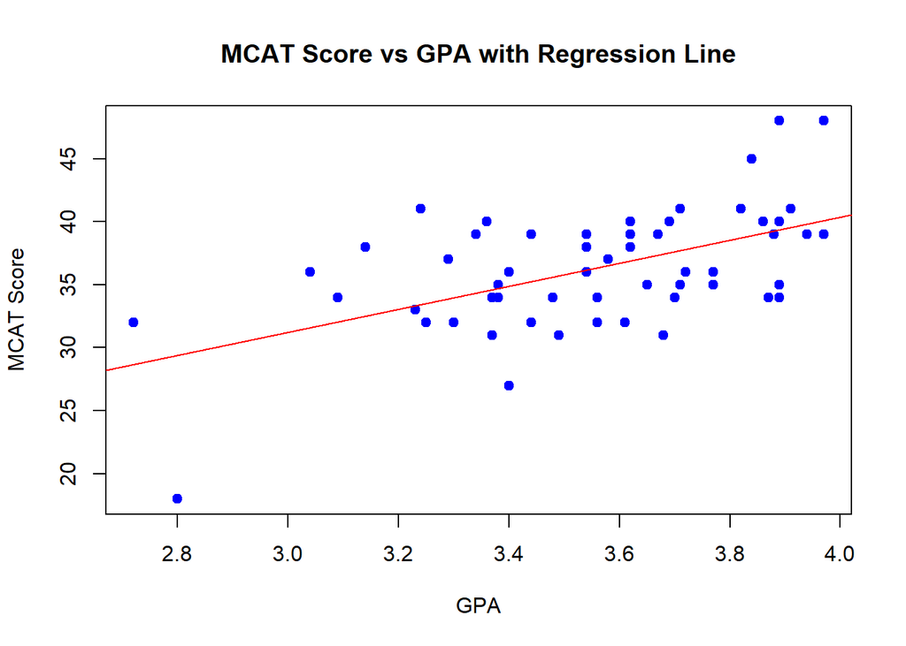

```r
# Sometimes you have to do the plot() and the abline() in one chunk and run the whole thing:
plot(mcat$GPA, mcat$MCAT, main="MCAT Score vs GPA with Regression Line", xlab="GPA", ylab="MCAT Score", pch=19, col="blue")
abline(lm_output_mcat, col="red")
```

**What is the slope of the regression line, and what does it mean?**

The slope of the regression line is 9.104. This means that for each unit increase in GPA, the MCAT score increases by approximately 9.104 points.

**What is the intercept and what does it mean?**

The intercept is 3.923. This represents the estimated MCAT score when the GPA is zero.

**What is your p-value?**

The p-value for the slope is 1.97e-05, indicating a statistically significant relationship between GPA and MCAT scores.

**What is your conclusion?**

There is a moderate and statistically significant positive relationship between GPA and MCAT scores. As GPA increases, the MCAT scores also increase significantly.

**What is the confidence interval for the slope?**

[5.208, 13.000]

```r
confint(lm_output_mcat)
```

```
                2.5 %   97.5 %
(Intercept) -9.961361 17.80724
GPA          5.209161 12.99928
```

**Interpret the confidence interval:**

The 95% confidence interval for the slope is approximately [5.208, 13.000]. This range does not include zero, indicating a significant relationship.

## Check Model Requirements

Check the normality of the residuals:

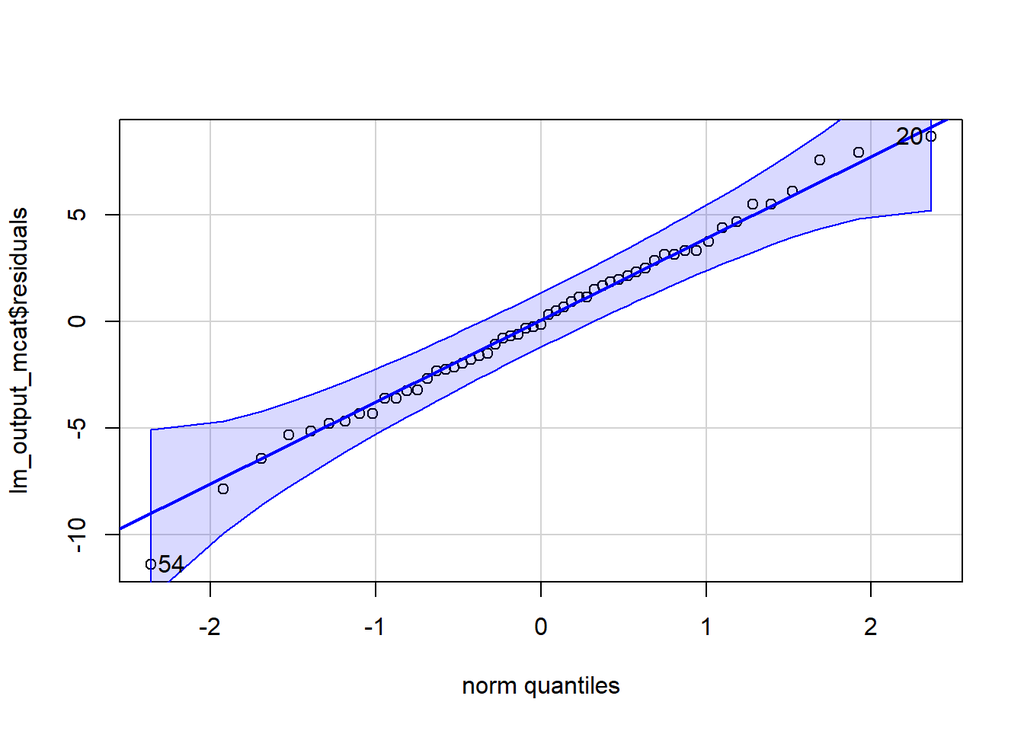

```
[1] 54 20
```

```r
qqPlot(lm_output_mcat$residuals)
```

Check for constant variance (Residual by Predicted plot):

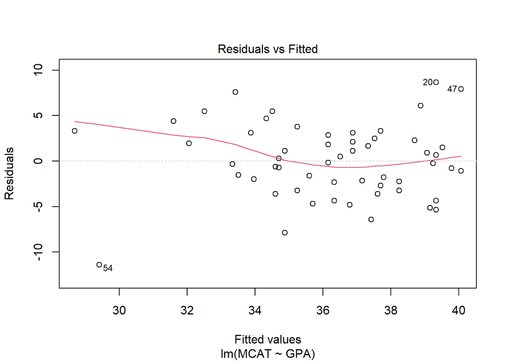

```r
plot(lm_output_mcat, which = 1)
```